# land4health-setup

This vignette shows how to install the required components and register a new user on the **Google Earth Engine platform**, in order to use its API within the `land4health` package to access and extract multiple variables relevant to **Spatial Epidemiology**.

## 1.1 What is Google Earth Engine?

[figure not shown]

**Google Earth Engine** is a cloud-based platform that helps access high-performance computing resources for processing and analyzing large geospatial datasets (Noel Golerick et al.,2017).

## 1.2 Objectives:

- Be accessible to various professionals without being experts in handling supercomputers.
- Reduce pre-post processing time of satellite images on a local, regional or global scale.
- Implement application development without being a backend/frontend expert.
- Boost the development of big data for remote sensing.

## 1.3 Components:

- **Data catalog**: Curated collection of several petabytes of geospatial datasets widely used in remote sensing available to the general public.
- **High performance computing service**: Google’s computational infrastructure to optimize parallel processing and distribution of geospatial data.
- **API and client libraries**: Application programming interface for making requests to Earth Engine servers.
  - API
    - Client libraries
    - Code Editor
    - REST API
  - Client libraries:
    - JavaScript
    - Python
    - R (no official)

## 1.4 Quickly review of Data catalog

[figure not shown]

# 2. Installation and setup land4health

## 2.1 GMAIL register

To access all the benefits offered by the Earth Engine platform, you must have an active Google (Gmail) account. To register, go to 👉 https://code.earthengine.google.com/register.

Earth Engine offers two registration options:

- **Commercial user**: For commercial product development, service monetization, and related purposes.
- **Non-commercial user**: For research, education, and academic activities.

For our purposes, we will proceed by selecting the non-commercial user option.

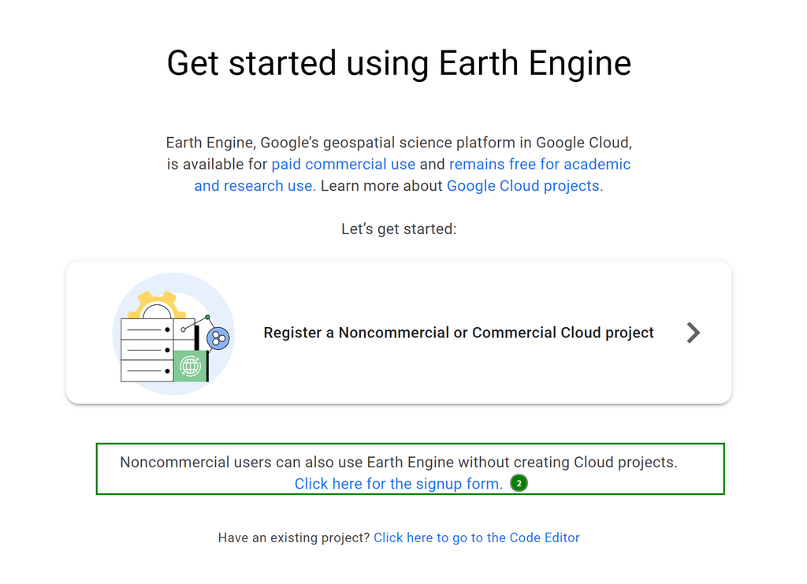

You can install the development version of `land4health` from GitHub with:

```r
# install.packages("pak")
pak::pkg_install("harmonize-tools/land4health")
```

```r
library(land4health)
```

```r
── Welcome to land4health ───────────────────────────────────────────────────────────────────────────────
A tool of Harmonize Project to calculate and extract Remote Sensing Metrics for Spatial Health Analysis.
Currently,`land4health` supports metrics in the following categories:
• Accesibility
• Climate
• Enviroment
• and more!
For a complete list of available metrics, use the `l4h_list_metrics()` function.

─────────────────────────────────────────────────────────────────────────────────────────────────────────
Attaching core land4health packages:
→ rgee v1.1.7
→ sf v1.0.21
```

```r
l4h_install()
```

```r
── Installing land4health Python dependencies ───────────────
ℹ Step 1/3: Checking Python environment
ℹ Step 2/3: Installing Python packages
✔ Python packages installed successfully
ℹ Step 3/3: Finalizing setup
✔ land4health setup completed.
```

```r
l4h_use_python()
rgee::ee_Initialize()
```

```
#> ── rgee 1.1.7 ─────────────────────────────────────── earthengine-api 0.1.370 ──
#>  ✔ user: not_defined
#>  ✔ Initializing Google Earth Engine: ✔ Initializing Google Earth Engine:  DONE!
#>  ✔ Earth Engine account: users/geografo2023
#>  ✔ Python Path: C:/Users/mvcs_dgppvu_ambi/AppData/Local/R/cache/R/reticulate/uv/cache/archive-v0/At8gJm7EZeLgoj4R1d2hk/Scripts/python.exe
#> ────────────────────────────────────────────────────────────────────────────────
```

```r
land4health::l4h_packages()
```

```
#> [1] "rgee"        "sf"          "land4health"
```